# Self-Driving Car Engineer Nanodegree

## Project: Build a Traffic Sign Recognition Classifier

In this notebook, a template is provided for you to implement your functionality in stages which is required to successfully complete this project. If additional code is required that cannot be included in the notebook, be sure that the Python code is successfully imported and included in your submission, if necessary. Sections that begin with **'Implementation'** in the header indicate where you should begin your implementation for your project. Note that some sections of implementation are optional, and will be marked with **'Optional'** in the header.

In addition to implementing code, there will be questions that you must answer which relate to the project and your implementation. Each section where you will answer a question is preceded by a **'Question'** header. Carefully read each question and provide thorough answers in the following text boxes that begin with **'Answer:'**. Your project submission will be evaluated based on your answers to each of the questions and the implementation you provide.

> **Note:** Code and Markdown cells can be executed using the **Shift + Enter** keyboard shortcut. In addition, Markdown cells can be edited by typically double-clicking the cell to enter edit mode.

## Step 0: Load The Data

```python
# Load pickled data
import pickle

# TODO: Fill this in based on where you saved the training and testing data

training_file = 'train.p'
testing_file = 'test.p'

with open(training_file, mode='rb') as f:
    train = pickle.load(f)
with open(testing_file, mode='rb') as f:
    test = pickle.load(f)

X_train, y_train = train['features'], train['labels']
X_test, y_test = test['features'], test['labels']

print("Data Loaded.")
```

```
Data Loaded.
```

## Step 1: Dataset Summary & Exploration

The pickled data is a dictionary with 4 key/value pairs:

- `'features'` is a 4D array containing raw pixel data of the traffic sign images, (num examples, width, height, channels).
- `'labels'` is a 2D array containing the label/class id of the traffic sign. The file `signnames.csv` contains id -> name mappings for each id.
- `'sizes'` is a list containing tuples, (width, height) representing the the original width and height the image.
- `'coords'` is a list containing tuples, (x1, y1, x2, y2) representing coordinates of a bounding box around the sign in the image. **THESE COORDINATES ASSUME THE ORIGINAL IMAGE. THE PICKLED DATA CONTAINS RESIZED VERSIONS (32 by 32) OF THESE IMAGES**

Complete the basic data summary below.

```python
### Replace each question mark with the appropriate value.

# TODO: Number of training examples
n_train = len(X_train)

# TODO: Number of testing examples.
n_test = len(X_test)

# TODO: What's the shape of an traffic sign image?
image_shape = X_train[0].shape

# TODO: How many unique classes/labels there are in the dataset.
n_classes = max(y_train)+1

print("Number of training examples =", n_train)
print("Number of testing examples =", n_test)
print("Image data shape =", image_shape)
print("Number of classes =", n_classes)
```

```
Number of training examples = 39209
Number of testing examples = 12630
Image data shape = (32, 32, 3)
Number of classes = 43
```

Visualize the German Traffic Signs Dataset using the pickled file(s). This is open ended, suggestions include: plotting traffic sign images, plotting the count of each sign, etc.

The [Matplotlib](http://matplotlib.org/) [examples](http://matplotlib.org/examples/index.html) and [gallery](http://matplotlib.org/gallery.html) pages are a great resource for doing visualizations in Python.

**NOTE:** It's recommended you start with something simple first. If you wish to do more, come back to it after you've completed the rest of the sections.

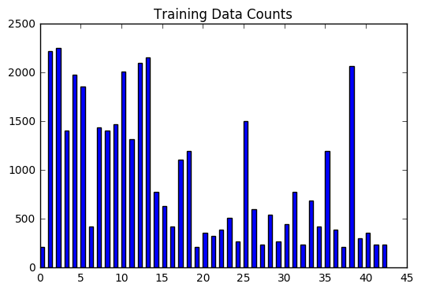

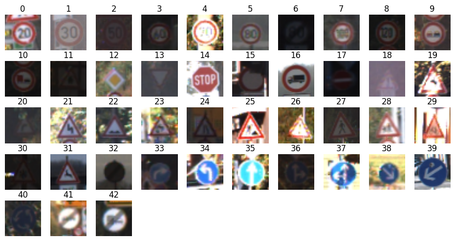

```python
### Data exploration visualization goes here.
### Feel free to use as many code cells as needed.
import random
import numpy as np
import matplotlib.pyplot as plt
import matplotlib.gridspec as gridspec
# Visualizations will be shown in the notebook.
%matplotlib inline

# plot a histogram of how many of each class are in the training and testing sets
bins = np.array(range(n_classes+1))
hist, edges = np.histogram(y_train, bins)
fig, ax = plt.subplots()
plt.title("Training Data Counts")
rects1 = ax.bar(range(n_classes), hist, width = 0.5, color='b')

# print one of each sign to see what they all look like
gs1 = gridspec.GridSpec(10, 10)
gs1.update(wspace=0.01, hspace=0.3) # set the spacing between axes.
plt.figure(figsize=(12,12))
for i in range(n_classes):
    indexes = np.where(y_train == i)[0]
    image = X_train[indexes[5]].squeeze()
    ax1 = plt.subplot(gs1[i])
    ax1.set_xticklabels([])
    ax1.set_yticklabels([])
    ax1.title.set_text(i)
    plt.imshow(image)
    plt.axis('off')
```

## Step 2: Design and Test a Model Architecture

Design and implement a deep learning model that learns to recognize traffic signs. Train and test your model on the [German Traffic Sign Dataset](http://benchmark.ini.rub.de/?section=gtsrb&subsection=dataset).

There are various aspects to consider when thinking about this problem:

- Neural network architecture
- Play around preprocessing techniques (normalization, rgb to grayscale, etc)
- Number of examples per label (some have more than others).
- Generate fake data.

Here is an example of a [published baseline model on this problem](http://yann.lecun.com/exdb/publis/pdf/sermanet-ijcnn-11.pdf). It's not required to be familiar with the approach used in the paper but, it's good practice to try to read papers like these.

**NOTE:** The LeNet-5 implementation shown in the classroom at the end of the CNN lesson is a solid starting point. You'll have to change the number of classes and possibly the preprocessing, but aside from that it's plug and play!

### Implementation

Use the code cell (or multiple code cells, if necessary) to implement the first step of your project. Once you have completed your implementation and are satisfied with the results, be sure to thoroughly answer the questions that follow.

```python
# function to generate greyscale image
import cv2

def toGreyscale(image):
    greyImg = cv2.cvtColor(image, cv2.COLOR_RGB2GRAY)
    greyImg = greyImg.reshape(greyImg.shape + (1,)) # ensure we have 1-size color channel
    return greyImg
```

```python
### Preprocess the data here.
### Feel free to use as many code cells as needed.

# Reading various sources it looks like grey scale does as well as
# color data, and sometimes beter.  So to simplify the project
# I will convert to greyscale images.

# 1) convert the training data
greyImages = []
for i in range(len(X_train)):
    greyImages.append(toGreyscale(X_train[i]) ) #grayscale conversion
greyImages = np.array(greyImages)
X_train = greyImages
print("Training images to greyscale", X_train.shape)

# 2) convert the test data also
greyTests = []
for i in range(len(X_test)):
    greyTests.append(toGreyscale(X_test[i]) ) #grayscale conversion
greyTests = np.array(greyTests)
X_test = greyTests
print("Test     images to greyscale", X_test.shape)
```

```
Training images to greyscale (39209, 32, 32, 1)
Test     images to greyscale (12630, 32, 32, 1)
```

### Question 1

*Describe how you preprocessed the data. Why did you choose that technique?*

**Answer:**

To preprocess the image data, I took all of the color images and changed them to greyscale. We did this on a lane finding exercise and it seemed to be a simple change and simplified the pipeline a bit. A few online sources implied that CNNs are able to work as well with greyscale . Originally I tried the CNN with color images, and when I added the greyscale preprocessing it performed a tiny bit better so I kept this step.

```python
# Add images to the training set

# Any training images with fewer than 500 samples will need more samples.
# This fucntion will take an image, rotate by +10 and -10 degrees.
def addTrainingImages(inX, inY):
    rotAngle = 10 # rotate each image by 10 degrees
    size = image_shape[0]
    center = size/2
    rot_M1 = cv2.getRotationMatrix2D((center,center), rotAngle,1)
    rot_M2 = cv2.getRotationMatrix2D((center,center),-rotAngle,1)

    numImages = len(inX)
    numLabels = n_classes
    bins = np.array(range(numLabels+1))
    hist, edges = np.histogram(inY, bins)

    newImages = []
    newLabels = []
    for i in range(numLabels):
        if hist[i] < 501:
            # find indexes with this class name
            indexes = np.where(inY == i)[0]
            for ii in indexes:
                imageRot = cv2.warpAffine(inX[ii],rot_M1,(size,size))
                newImages.append(imageRot)
                newLabels.append(i)
                imageRot = cv2.warpAffine(inX[ii],rot_M2,(size,size))
                newImages.append(imageRot)
                newLabels.append(i)

    newImages = np.array(newImages)
    newImages = newImages.reshape(newImages.shape + (1,)) # ensure we have 1 color channel

    X_full = np.append(inX, newImages, axis=0)
    y_full = np.append(inY, newLabels, axis=0)
    print("Images and labels added: ",len(X_full)-numImages)
    return X_full, y_full
```

```
Images and labels added:  11940
Final Training   size:  48591
Final Validation size:  2558
Data shuffled
```

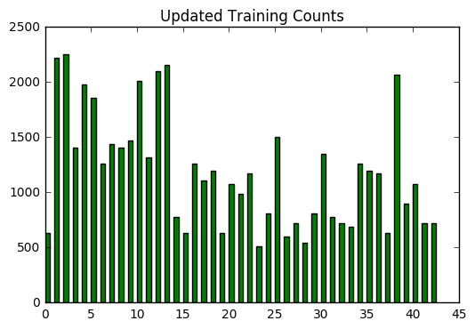

```python
### Generate data additional data (OPTIONAL!)
### and split the data into training/validation/testing sets here.
### Feel free to use as many code cells as needed.

X_train, y_train = addTrainingImages(X_train, y_train)
# compute updated histogram
hist, edges = np.histogram(y_train, bins)
fig, ax = plt.subplots()
plt.title("Updated Training Counts")
rects1 = ax.bar(range(n_classes), hist, width = 0.5, color='g')


# Now we will split the training data into training and validation sets
VAL_RATIO = 0.05

from sklearn.utils import shuffle
from sklearn.model_selection import train_test_split

X_train, X_validation, y_train, y_validation = train_test_split(X_train, y_train, test_size=VAL_RATIO, random_state=15)
print("Final Training   size: ", len(X_train))
print("Final Validation size: ", len(X_validation))



# To aviod training on the order of our images, we will also shuffle
# the training set
X_train, y_train = shuffle(X_train, y_train)
print("Data shuffled")
```

### Question 2

*Describe how you set up the training, validation and testing data for your model. **Optional**: If you generated additional data, how did you generate the data? Why did you generate the data? What are the differences in the new dataset (with generated data) from the original dataset?*

**Answer:**

There were 3 steps to setting up the training data.

1. Adding some additional images by modifying existing data
2. Splitting the training data into a training set and validation set
3. Shuffling the training data

Step 1: How did you generate the data?

The new images were generated by taking an existing image, and rotating the image by 10 degrees to the right, and 10 degrees to the left. This was done for every example image of that sign class.

Step 1: Why did you generate the data?

I noted that several of the sign classes had fewer than 500 training example images, while others had over 2000. In order to make the training set of images a bit more even, I added more instances of any sign classes that had 500 or less examples.

Step 1: What are the differences in the new dataset?

For every sign class with 500 or less examples, this process effectively tripled the number of images for the sign classes with low image counts. The updated histogram count of each sign class is shown above.

Step 2:

To train the model, the optimizer will optimize the weights and biases using the classifications of the training images. When we finish a single epoch (1 time through the complete training set of images) the pipeline will then try the weights and biases with a set-aside group of images called the validation set. The evaluate() function below will perform this validation check and report the performance of the model's weights and biases at the end of that epoch. The training loop will then move on to the next epoch. I chose 5% since that was used on some class room examples, and through some trial and error testing.

Step 3:

As a final step I shuffle the training data. Shuffling will prevent the optimizer from training to the order of the training images.

```python
### Define your architecture here.
### Feel free to use as many code cells as needed.
import tensorflow as tf
from tensorflow.contrib.layers import flatten

# global settings
MU = 0
SIGMA = 0.05
EPOCHS = 30
BATCH_SIZE = 128
FILTER_SIZE = 5
LEARNING_RATE = 0.001

# convenience function to generate a convolutional variable
def genConvVar(filter_size, depth1, depth2):
    return tf.Variable(tf.truncated_normal([filter_size, filter_size, depth1, depth2], mean=MU, stddev=SIGMA))

# convenience function to generate a flat matrix variable
def genFlatVar(depth1, depth2):
    return tf.Variable(tf.truncated_normal([depth1, depth2], mean=MU, stddev=SIGMA))
```

```python
# Network inputs

layer_depths = {
    'layer_0': 1, # starting with 1 color (greyscale)
    'layer_1': 12,
    'layer_2': 24,
    'layer_3': 120,
    'layer_4': 84,
    'layer_5': n_classes
}
layer_2_flat_size = FILTER_SIZE*FILTER_SIZE * layer_depths['layer_2']

weights = {
    'layer_1': genConvVar(FILTER_SIZE, layer_depths['layer_0'], layer_depths['layer_1']),
    'layer_2': genConvVar(FILTER_SIZE, layer_depths['layer_1'], layer_depths['layer_2']),
    'layer_3': genFlatVar(layer_2_flat_size,      layer_depths['layer_3']),
    'layer_4': genFlatVar(layer_depths['layer_3'], layer_depths['layer_4']),
    'layer_5': genFlatVar(layer_depths['layer_4'], layer_depths['layer_5'])
}
biases = {
    'layer_1': tf.Variable(tf.zeros(layer_depths['layer_1'])),
    'layer_2': tf.Variable(tf.zeros(layer_depths['layer_2'])),
    'layer_3': tf.Variable(tf.zeros(layer_depths['layer_3'])),
    'layer_4': tf.Variable(tf.zeros(layer_depths['layer_4'])),
    'layer_5': tf.Variable(tf.zeros(layer_depths['layer_5']))
}
```

```python
# Model definition

strides_NN   = [1,1,1,1]
strides_Pool = [1,2,2,1]

def LeNet(x):
    # Layer 1: Convolution.
    x = tf.nn.conv2d(x, weights['layer_1'], strides=strides_NN, padding='VALID')
    x = tf.nn.bias_add(x, biases['layer_1'])
    x = tf.nn.relu(x)# Activation.
    lay1_out = tf.nn.max_pool(x, ksize=strides_Pool, strides=strides_Pool, padding='VALID')

    # Layer 2: Convolution.
    x = tf.nn.conv2d(lay1_out, weights['layer_2'], strides=strides_NN, padding='VALID')
    x = tf.nn.bias_add(x, biases['layer_2'])
    x = tf.nn.relu(x) # Activation.
    lay2_out = tf.nn.max_pool(x, ksize=strides_Pool, strides=strides_Pool, padding='VALID')
    # Flatten for next layer
    lay2_flat = tf.contrib.layers.flatten(lay2_out)

    # Layer 3: Fully Connected.
    x = tf.add(tf.matmul(lay2_flat, weights['layer_3']), biases['layer_3'])
    lay3_out = tf.nn.relu(x)# Activation.

    # Layer 4: Fully Connected.
    x = tf.add(tf.matmul(lay3_out, weights['layer_4']), biases['layer_4'])
    lay4_out = tf.nn.relu(x)# Activation.

    # Layer 5: Fully Connected. Final
    logits = tf.add(tf.matmul(lay4_out, weights['layer_5']), biases['layer_5'])

    return logits
```

### Question 3

*What does your final architecture look like? (Type of model, layers, sizes, connectivity, etc.) For reference on how to build a deep neural network using TensorFlow, see Deep Neural Network in TensorFlow from the classroom.*

**Answer:**

My final architecture is the LeNet CNN architecture given in the final lesson for this project. In order to best understand the model, I re-wrote the code that generates the model and gathered all of the inputs into the first 2 cells. The first cell above contains the global hyper-parameters for the network. The second cell sets the layer depths and builds all of the tensor flow variables needed for the network.

In the model definition cell, I wire up the 5 layers from the input dictionaries above. The network consists of 2 Convolution layers, followed by 3 fully-connected layers. The final fully-connected layer produces the classification into the 43 classes. The final network sizes were:

1. Conv - input: 32x32x1 -> filters: 12 at 5x5 -> output: 28x28x12
   1. ReLU activation -> output: 28x28x12
   2. Max Pooling -> output: 14x14x12
2. Conv - input: 14x14x12 -> filters: 24 at 5x5 -> output: 10x10x24
   1. ReLU activation -> output: 10x10x24
   2. Max Pooling -> output: 5x5x24
   3. Flatten matrix -> output: 600x1
3. FC - input: 600x1 -> output: 120x1 (ReLU activation)
4. FC - input: 120x1 -> output: 84x1 (ReLU activation)
5. FC - input: 84x1 -> output: 43x1

I tried various depth levels for various layers. By adding filters to the Convolution layers the accuracy of the model in the validation steps went up by about 2%.

```python
# Set up input variables
x = tf.placeholder(tf.float32, (None, 32, 32, 1))
y = tf.placeholder(tf.int32, (None))
one_hot_y = tf.one_hot(y, n_classes)
```

```python
# Set up the training pipeline
logits = LeNet(x)
cross_entropy = tf.nn.softmax_cross_entropy_with_logits(logits, one_hot_y)
loss_operation = tf.reduce_mean(cross_entropy)
optimizer = tf.train.AdamOptimizer(learning_rate = LEARNING_RATE)
training_operation = optimizer.minimize(loss_operation)
```

```python
# set up training evaluation system
correct_prediction = tf.equal(tf.argmax(logits, 1), tf.argmax(one_hot_y, 1))
accuracy_operation = tf.reduce_mean(tf.cast(correct_prediction, tf.float32))
saver = tf.train.Saver()

def evaluate(X_data, y_data):
    num_examples = len(X_data)
    total_accuracy = 0
    sess = tf.get_default_session()
    for offset in range(0, num_examples, BATCH_SIZE):
        batch_x, batch_y = X_data[offset:offset+BATCH_SIZE], y_data[offset:offset+BATCH_SIZE]
        accuracy = sess.run(accuracy_operation, feed_dict={x: batch_x, y: batch_y})
        total_accuracy += (accuracy * len(batch_x))
    return total_accuracy / num_examples
```

```python
### Train your model here.
### Feel free to use as many code cells as needed.

with tf.Session() as sess:
    sess.run(tf.global_variables_initializer())
    num_examples = len(X_train)

    print("Training...")
    print()
    for i in range(EPOCHS):
        batch_i = 0
        X_train, y_train = shuffle(X_train, y_train)
        for offset in range(0, num_examples, BATCH_SIZE):
            batch_i += 1
            end = offset + BATCH_SIZE
            batch_x, batch_y = X_train[offset:end], y_train[offset:end]
            sess.run(training_operation, feed_dict={x: batch_x, y: batch_y})

        validation_accuracy = evaluate(X_validation, y_validation)
        print("EPOCH {} ...".format(i+1))
        print("Validation Accuracy = {:.3f}".format(validation_accuracy))
        print()

    saver.save(sess, 'lenet')
    print("Model saved")
```

```
Training...

EPOCH 1 ...
Validation Accuracy = 0.923

EPOCH 2 ...
Validation Accuracy = 0.953

EPOCH 3 ...
Validation Accuracy = 0.975

EPOCH 4 ...
Validation Accuracy = 0.980

EPOCH 5 ...
Validation Accuracy = 0.977

EPOCH 6 ...
Validation Accuracy = 0.971

EPOCH 7 ...
Validation Accuracy = 0.985

EPOCH 8 ...
Validation Accuracy = 0.984

EPOCH 9 ...
Validation Accuracy = 0.987

EPOCH 10 ...
Validation Accuracy = 0.983

EPOCH 11 ...
Validation Accuracy = 0.977

EPOCH 12 ...
Validation Accuracy = 0.990

EPOCH 13 ...
Validation Accuracy = 0.989
```

[output cut: 38 more lines]

```
Validation Accuracy = 0.988

EPOCH 27 ...
Validation Accuracy = 0.988

EPOCH 28 ...
Validation Accuracy = 0.989

EPOCH 29 ...
Validation Accuracy = 0.991

EPOCH 30 ...
Validation Accuracy = 0.987

Model saved
```

```python
with tf.Session() as sess:
    saver.restore(sess, tf.train.latest_checkpoint('.'))

    test_accuracy = evaluate(X_test, y_test)
    print("Test Accuracy = {:.3f}".format(test_accuracy))
```

```
Test Accuracy = 0.937
```

### Question 4

*How did you train your model? (Type of optimizer, batch size, epochs, hyperparameters, etc.)*

**Answer:**

For training I used the procedures from the LeNet examples from the lessons.

Step 1: I set up input variables for tensor flow. "x" was used for the input images, and "y" was used for the 1-hot-encoded classification key.

Step 2: The pipeline starts by calling the LeNet model with the input images. From there the TensorFlow API provides a function to calculate the softmax values for each input image logits, and automatically compare the softmax values to the one-hot encoded class key returning the cross entropy matrix. TensorFlow also provides a function to calculate the average value for the cross entropy (our error). Given the average error, the Adam optimizer was used to minimize this error. The Adam optimizer was chosen because it is able to converge a bit faster than a basic gradient descent optimizer. Adam uses momentum to help convergence with larger step sizes. Adam will incur more resource utilization, so an AWS "g2.2xlarge" was used for training.

Step 3: I set up a function to evaluate the accuracy of the trained model versus some validation images. This pipeline takes the max value of the logits vector (giving the predicted class) and checks to see if it is equal to the one-hot-encoded answer key. This is done for the entire batch of predictions, and then the average value is calculated across the whole set. There is then a loop to go over all the batches of images to compute this average, and the overall average accuracy is then reported back.

Step 4: For the training process, the training loop will iterate for the given number of epochs given. For each epoch, a loop will run a batch of images (defined by the BATCH_SIZE setting defined above) and run the "training_operation" function in TensorFlow. Once a batch is finished it will move on to the next batch until all the images are complete. At that point the validation operation will run to log the accuracy at this point in the training. I tried batch sizes of 64, 128, and 256. They all performed about the same, but the 128 batch size was a tiny bit better, so that was the final value used for training. I tried epochs of 5, 10, 15, 25, and 30. 30 epochs gave the best results, but didn't improve much the last few epochs, so I didn't see a need to do further epochs.

Another hyper-parameter changed was the SIGMA value used to initialize the weights and bias terms. Originally a value of 0.1 was used, but changing it to 0.05 added about 1.5% to the validation accuracy.

For comparison purposes, I trained the entire model without any extra training data and achieved a validation accuracy of about 98%. When I included the extra training data described above in the pre-processing section the validation accuracy rose to a max of 99.2% (seen above). Using the test data with the original data set showed an accuracy of 92%, and with the augmented training data it rose to 93.7%. It seems that with even better image data generation it would be possible to improve the accuracy of the model.

### Question 5

*What approach did you take in coming up with a solution to this problem? It may have been a process of trial and error, in which case, outline the steps you took to get to the final solution and why you chose those steps. Perhaps your solution involved an already well known implementation or architecture. In this case, discuss why you think this is suitable for the current problem.*

**Answer:**

I am completely new to neural networks, so reading online about them is very interesting, and the course material was extremely well done in introducing me to all the concepts. After going through the project introduction, and reading a couple online sources about LeNet, the LeNet architecture appeared to have a good mix of simplicity, run-time speed, and good accuracy. Judging from other online writings, a simple linear fully-connected network would be difficult to train on traffic signs.

Since I was going to use LeNet, I took some time to re-implement the model with code that I could go through step-by-step, and also allow me to quickly change the sizes and depths of the different layers. This process helped me better understand the CNN architecture and finally get a better intuition of what is going on with the training.

Once the architecture was set, I began a long sequence of trial and error. I tried different layer depths, different batch sizes, different epoch counts, different validation set sizes, and different sigma values. After each of these runs I would store the final validation accuracy and try to keep parameter values that led to the best accuracies. Once it was getting really good results (>97%) I then calculated the accuracy on the test set of images. The test set had lower accuracy than the validation set, but still greater than 93%.

## Step 3: Test a Model on New Images

Take several pictures of traffic signs that you find on the web or around you (at least five), and run them through your classifier on your computer to produce example results. The classifier might not recognize some local signs but it could prove interesting nonetheless.

You may find `signnames.csv` useful as it contains mappings from the class id (integer) to the actual sign name.

### Implementation

Use the code cell (or multiple code cells, if necessary) to implement the first step of your project. Once you have completed your implementation and are satisfied with the results, be sure to thoroughly answer the questions that follow.

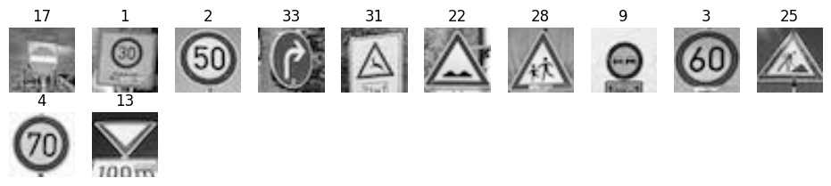

```python
### Load the images and plot them here.
### Feel free to use as many code cells as needed.
import os
import matplotlib.image as mpimg

new_images = []
new_labels = []
fileNames = os.listdir("new_images/")
for fileName in fileNames:
    if 'jpg' not in fileName and 'jpeg' not in fileName:
        continue
    basename = fileName.split('.')[0]
    signID   = basename.split(',')[1]
    fullName = os.path.join("new_images",fileName)
    image = mpimg.imread(fullName)
    image = toGreyscale(image)
    new_images.append(image)
    new_labels.append(int(signID))

new_images = np.array(new_images)
new_labels = np.array(new_labels)


# plot each test image to see what they all look like
gs1 = gridspec.GridSpec(10, 10)
gs1.update(wspace=0.01, hspace=0.3) # set the spacing between axes.
plt.figure(figsize=(12,12))
for i in range(len(new_labels)):
    image = new_images[i].squeeze()
    ax1 = plt.subplot(gs1[i])
    ax1.set_xticklabels([])
    ax1.set_yticklabels([])
    ax1.title.set_text(new_labels[i])
    plt.imshow(image, cmap='gray')
    plt.axis('off')
```

### Question 6

*Choose five candidate images of traffic signs and provide them in the report. Are there any particular qualities of the image(s) that might make classification difficult? It could be helpful to plot the images in the notebook.*

**Answer:**

I did a web search for German traffic signs, and ended up with 12 that would be good test candidates. I manually cropped the images and resized them to 32x32x3. I then used the labels guide to classify them all by visual inspection. The classification I picked was then encoded into the filename so that the code could load the image and the class label at the same time.

These images have a good mix of quality. Some should be easy to classify, and some will be hard. For the harder ones, there are pixilation issues, different shadings, and sometimes other items are cropped into the image with the sign. See above for plots of these test images.

```python
### Run the predictions here.
### Feel free to use as many code cells as needed.

with tf.Session() as sess:
    saver.restore(sess, tf.train.latest_checkpoint('.'))

    test_accuracy = evaluate(new_images, new_labels)
    print("Test Accuracy = {:.3f}".format(test_accuracy))
```

```
Test Accuracy = 0.750
```

### Question 7

*Is your model able to perform equally well on captured pictures when compared to testing on the dataset? The simplest way to do this check the accuracy of the predictions. For example, if the model predicted 1 out of 5 signs correctly, it's 20% accurate.*

**NOTE:** You could check the accuracy manually by using `signnames.csv` (same directory). This file has a mapping from the class id (0-42) to the corresponding sign name. So, you could take the class id the model outputs, lookup the name in `signnames.csv` and see if it matches the sign from the image.

**Answer:**

The model ends up having an accuracy of about 75%. So there were 3 wrong out of the 12 test images. 75% is much lower than I was hoping for. Visually inspecting the images it seems that they were certainly good enough to be classified. See below for a list of images that were wrong.

```python
### Visualize the softmax probabilities here.
### Feel free to use as many code cells as needed.

softmax_calc = tf.nn.softmax(logits)
top5 = tf.nn.top_k(softmax_calc, k=4)

with tf.Session() as sess:
    saver.restore(sess, tf.train.latest_checkpoint('.'))
    best = sess.run(top5, feed_dict={x: new_images, y: new_labels})
    print("Certanties:")
    print(best[0])
    print("Top 5 picks:")
    print(best[1])
    print("Actual answer key:")
    print(new_labels)

# look at sign vs errors

for i in range(len(new_labels)):
    foundClass = best[1][i][0]
    rightClass = new_labels[i]
    if foundClass != rightClass:
        print("Wrong: Image {:2d} classed as {:2d}, should be {:2d}".format(i,foundClass,rightClass))
```

```
Certanties:
[[  1.00000000e+00   8.49296744e-11   4.55471672e-14   1.14927315e-15]
 [  1.00000000e+00   1.05785614e-14   1.98370550e-16   1.33907134e-16]
 [  9.99996424e-01   3.56892178e-06   2.05225760e-16   5.41049074e-22]
 [  1.00000000e+00   0.00000000e+00   0.00000000e+00   0.00000000e+00]
 [  1.00000000e+00   3.23502400e-33   7.99686339e-35   6.22473391e-35]
 [  1.00000000e+00   5.93428600e-37   0.00000000e+00   0.00000000e+00]
 [  1.00000000e+00   3.55279922e-20   2.25385569e-20   2.70744458e-24]
 [  1.00000000e+00   6.44029331e-33   0.00000000e+00   0.00000000e+00]
 [  9.99996066e-01   3.94822018e-06   3.27508474e-08   4.70983563e-09]
 [  1.00000000e+00   3.74192375e-36   2.45777745e-38   0.00000000e+00]
 [  1.00000000e+00   8.19807666e-10   5.19029535e-13   8.42460533e-23]
 [  1.00000000e+00   4.78106812e-28   7.45142655e-34   1.07225915e-36]]
Top 5 picks:
[[13 17  9 33]
 [12 40 11 23]
 [ 1  0  2  4]
 [33  0  1  2]
 [31 24 23 29]
 [22 29  0  1]
 [28 35 11 20]
 [ 9 16  0  1]
 [ 3  2  0  5]
 [25 24 23  0]
 [ 4  1  0 33]
 [13  1 33  5]]
Actual answer key:
[17  1  2 33 31 22 28  9  3 25  4 13]
Wrong: Image  0 classed as 13, should be 17
Wrong: Image  1 classed as 12, should be  1
Wrong: Image  2 classed as  1, should be  2
```

```
Columns: Test Image,    Classified as,    Should be
```

[figure not shown]

[figure not shown]

[figure not shown]

```python
# look at sign vs errors
print("Columns: Test Image,    Classified as,    Should be")
for i in range(len(new_labels)):
    foundClass = best[1][i][0]
    rightClass = new_labels[i]
    if foundClass == rightClass:
        continue
    wrongIndex = np.where(y_train == foundClass)[0][0]
    rightIndex = np.where(y_train == rightClass)[0][0]
    f, (ax1, ax2, ax3) = plt.subplots(1, 3)
    ax1.title.set_text(new_labels[i])
    ax2.title.set_text(foundClass)
    ax3.title.set_text(rightClass)
    image1 = new_images[i].squeeze()
    image2 = X_train[wrongIndex].squeeze()
    image3 = X_train[rightIndex].squeeze()
    ax1.imshow(image1, cmap='gray')
    ax2.imshow(image2, cmap='gray')
    ax3.imshow(image3, cmap='gray')
```

### Question 8

*Use the model's softmax probabilities to visualize the **certainty** of its predictions, [`tf.nn.top_k`](https://www.tensorflow.org/versions/r0.12/api_docs/python/nn.html#top_k) could prove helpful here. Which predictions is the model certain of? Uncertain? If the model was incorrect in its initial prediction, does the correct prediction appear in the top k? (k should be 5 at most)*

`tf.nn.top_k` will return the values and indices (class ids) of the top k predictions. So if k=3, for each sign, it'll return the 3 largest probabilities (out of a possible 43) and the correspoding class ids.

Take this numpy array as an example:

```
# (5, 6) array
a = np.array([[ 0.24879643,  0.07032244,  0.12641572,  0.34763842,  0.07893497,
         0.12789202],
       [ 0.28086119,  0.27569815,  0.08594638,  0.0178669 ,  0.18063401,
         0.15899337],
       [ 0.26076848,  0.23664738,  0.08020603,  0.07001922,  0.1134371 ,
         0.23892179],
       [ 0.11943333,  0.29198961,  0.02605103,  0.26234032,  0.1351348 ,
         0.16505091],
       [ 0.09561176,  0.34396535,  0.0643941 ,  0.16240774,  0.24206137,
         0.09155967]])
```

Running it through `sess.run(tf.nn.top_k(tf.constant(a), k=3))` produces:

```
TopKV2(values=array([[ 0.34763842,  0.24879643,  0.12789202],
       [ 0.28086119,  0.27569815,  0.18063401],
       [ 0.26076848,  0.23892179,  0.23664738],
       [ 0.29198961,  0.26234032,  0.16505091],
       [ 0.34396535,  0.24206137,  0.16240774]]), indices=array([[3, 0, 5],
       [0, 1, 4],
       [0, 5, 1],
       [1, 3, 5],
       [1, 4, 3]], dtype=int32))
```

Looking just at the first row we get `[ 0.34763842, 0.24879643, 0.12789202]`, you can confirm these are the 3 largest probabilities in `a`. You'll also notice `[3, 0, 5]` are the corresponding indices.

**Answer:**

Looking at the softmax values using the top_k function (with k=4) I can see the top 4 picks for each test image. I am surprised at how high the confidence values are. There were several 1.0 confidence values, even when the classification was wrong! For the incorrect images we see:

- 1.0 confidence, but picked wrong class (second place was right!)
- 1.0 confidence, but picked wrong class (all top 4 wrong)
- 0.999 confidence, but picked wrong class (third place pick was right!)

So for the 3 that were wrong, the second or third choice would have been the proper choice for 2 of them. Interesting results. See above for plots of the images versus what they should have been classified to.

## Sources Used

For this project I did a good amount of research and learned several new techniques for data processing. Here is a (mostly complete) list of very helpful sources.

- Udacity [LeNet Lab](https://github.com/udacity/CarND-LeNet-Lab)
- Hvass Laboratories [TensorFlow Tutorials](https://github.com/Hvass-Labs/TensorFlow-Tutorials)
- pyimagesearch [Basic Image Manipulations](http://www.pyimagesearch.com/2014/01/20/basic-image-manipulations-in-python-and-opencv-resizing-scaling-rotating-and-cropping/)
- OpenCV [Python transformations](http://docs.opencv.org/3.0-beta/doc/py_tutorials/py_imgproc/py_geometric_transformations/py_geometric_transformations.html)
- Wikipedia [CNN](https://en.wikipedia.org/wiki/Convolutional_neural_network)

And of course not much would happen without [StackOverflow](http://stackoverflow.com)!